# 16 Reproducible examples

## 16.1 Why use **reprex**?

The motivation below is copied directly from: https://www.tidyverse.org/help/

If you need help getting unstuck, the first step is to create a **reprex**, or reproducible example. The goal of a reprex is to package your problematic code in such a way that other people can run it and feel your pain. Then, hopefully, they can provide a solution and put you out of your misery.

There are two parts to creating a reprex:

- First, you need to make your code reproducible. This means that you need to capture everything, i.e., include any library() calls and create all necessary objects. The easiest way to make sure you’ve done this is to use the reprex package.
- Second, you need to make it minimal. Strip away everything that is not directly related to your problem. This usually involves creating a much smaller and simpler R object than the one you’re facing in real life or even using built-in data.

That sounds like a lot of work! And it can be, but it has a great payoff:

- 80% of the time creating an excellent reprex reveals the source of your problem. It’s amazing how often the process of writing up a self-contained and minimal example allows you to answer your own question.
- The other 20% of time you will have captured the essence of your problem in a way that is easy for others to play with. This substantially improves your chances of getting help!

## 16.2 `reprex()`

> Help me help you

In order to create a `repr`oducible `ex`ample …

Step 1. Write some R code and copy it into the clipboard (command-c or ctrl-c).

Step 2. Type `reprex()` into the Console.

Step 3. Look at the Viewer to the right. Copy the Viewer output into GitHub, Slack, an email, [Stack Overflow](https://stackoverflow.com/), [Posit Community](https://forum.posit.co/), etc.

Some places to learn more about `reprex` include

- A blog about it: https://teachdatascience.com/reprex/
- The `reprex` vignette: https://reprex.tidyverse.org/index.html
- `reprex` dos and don’ts: https://reprex.tidyverse.org/articles/reprex-dos-and-donts.html
- Jenny Bryan webinar on `reprex`: “Help me help you. Creating reproducible examples” https://opensource.posit.co/resources/videos/2021-04-03_jenny-bryan-help-me-help-you-creating-reproducible-examples-rstudio-2018/
- Some advice: https://stackoverflow.com/help/minimal-reproducible-example

## 16.3 `reprex` demo

Let’s say I want to send out a query to help me understand what happens when I add months and days to January 31.

### 16.3.1 First try

Code:

```r
jan31 + months(0:11) + days(31)
```

Output of `reprex()`:

```r
jan31 + months(0:11) + days(31)
```

```
#> Error in eval(expr, envir, enclos): object 'jan31' not found
```

The error tells me that there isn’t an object called `jan31`. So if I want my friend to try to reproduce my results, they won’t be able to do it on their computer (assuming they don’t have an object named `jan31`).

### 16.3.2 Second try

Code:

```r
jan31 <- ymd("2021-01-31")
jan31 + months(0:11) + days(31)
```

Output of `reprex()`:

```r
jan31 <- ymd("2021-01-31")
```

```
#> Error in ymd("2021-01-31"): could not find function "ymd"
```

```r
jan31 + months(0:11) + days(31)
```

```
#> Error in eval(expr, envir, enclos): object 'jan31' not found
```

Now the error is that the `ymd()` function can’t be found. That is because I didn’t load in the **lubridate** package!

### 16.3.3 Third try

Code:

```r
library(lubridate)
jan31 <- ymd("2021-01-31")
jan31 + months(0:11) + days(31)
```

Output of `reprex()`:

```r
library(lubridate)
jan31 <- ymd("2021-01-31")
jan31 + months(0:11) + days(31)
```

```
#>  [1] "2021-03-03" NA           "2021-05-01" NA           "2021-07-01"
#>  [6] NA           "2021-08-31" "2021-10-01" NA           "2021-12-01"
#> [11] NA           "2022-01-31"
```

On the third try, I get the output that I expect to get (and don’t understand)! I can now copy the output of the **reprex** and send it to a friend or message board to get help understand why the output is what it is.

## 16.4 Reproducible example w ChatGPT

> generate a reprex in R to demonstrate how to reorder a factor variable

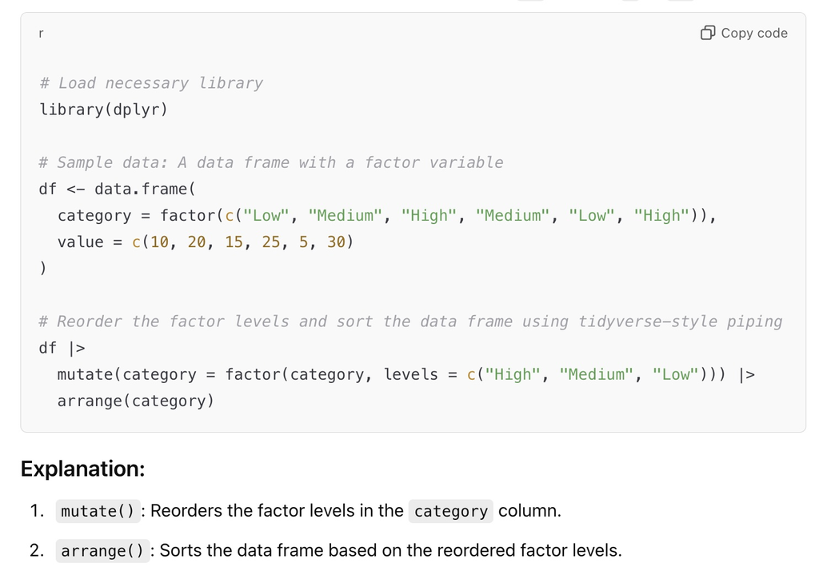

## 16.5 Must-haves for `reprex()`

The following must be included in order for a reproducible example to work (i.e., for someone else to run the code and get the same output):

- R packages
- relevant dataset(s)
- all of the code

## 16.6 Checklist for a good `reprex()`

✅ Minimal  
✅ Complete  
✅ Runnable  
✅ Clearly explains the problem

## 16.7 Reflection questions

- What are the pieces of a reproducible example?
- What are the common things that you might forget to provide to your collaborator when sending them a reproducible example?

## 16.8 Ethics considerations

- Why is it important to be able to condense the question into a reproducible example?
- What might happen in the process of creating a reproducible example?[^1]

## 16.9 References

[^1]: You might solve your own problem!